# US Flights 2018 Dataset

# we will present: Arrival and departure total delays by month of the year (2018)

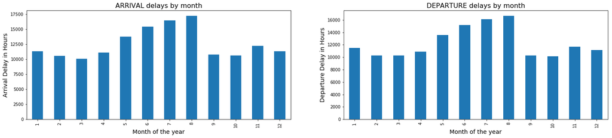

```python
# Arrival and departure delays by month of the year
plt.figure(figsize=(25, 12)).subplots_adjust(hspace = 0.5)

plt.subplot(2, 2 ,1)
df1=flights.query('ARR_DELAY_HR > 0')
df1.groupby('FL_DATE_month').ARR_DELAY_HR.sum().plot.bar(color=base_color)
plt.title('ARRIVAL delays by month', fontsize=16)
plt.ylabel('Arrival Delay in Hours', fontsize=14)
plt.xlabel('Month of the year', fontsize=14)

plt.subplot(2, 2 ,2)
df2=flights.query('DEP_DELAY_HR > 0')
df2.groupby('FL_DATE_month').DEP_DELAY_HR.sum().plot.bar(color=base_color)
plt.title('DEPARTURE delays by month', fontsize=16)
plt.ylabel('Departure Delay in Hours', fontsize=14)
plt.xlabel('Month of the year', fontsize=14);
```

# ORIGIN and OP_CARRIER for TOP5 Airports in clustered bar charts

```python
df4=flights.groupby('ORIGIN').count()
df4['OP_CARRIER'].nlargest(5)
```

```
ORIGIN
ATL    36585
ORD    30955
DFW    26125
DEN    22254
CLT    21804
Name: OP_CARRIER, dtype: int64
```

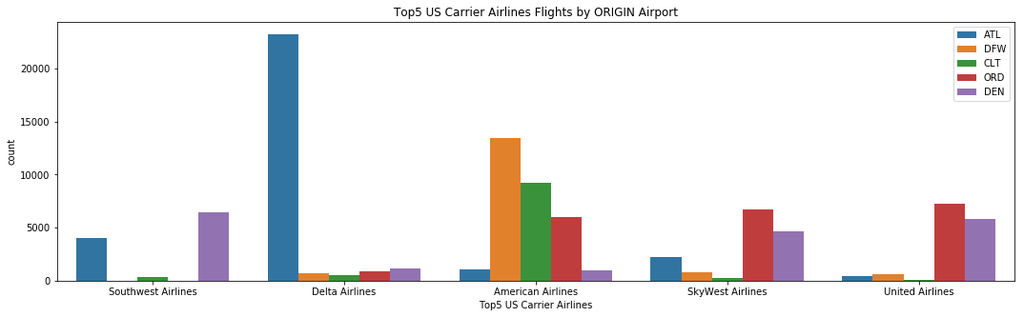

```python
##### TOP5 OP_CARRIER VS Top 5 ORIGIN
carrier_classes =['Southwest Airlines','Delta Airlines','American Airlines', 'SkyWest Airlines', 'United Airlines']
vclasses = pd.api.types.CategoricalDtype(ordered=True, categories=carrier_classes)
flights['VClass'] = flights['OP_CARRIER_NAME'].astype(vclasses);
df5=flights.query('ORIGIN=="ATL" or ORIGIN=="ORD" or ORIGIN=="DFW" or ORIGIN=="DEN" or ORIGIN=="CLT"')
ct_counts = df5.groupby(['VClass', 'ORIGIN']).size()
# Use Series.reset_index() to convert a series into a dataframe object
ct_counts = ct_counts.reset_index(name='count')
# Use DataFrame.pivot() to rearrange the data, to have vehicle class on rows
ct_counts = ct_counts.pivot(index = 'VClass', columns = 'ORIGIN', values = 'count')
ct_counts
#sb.heatmap(ct_counts)
sb.countplot(data = df5, x = 'VClass', hue = 'ORIGIN')
plt.title("Top5 US Carrier Airlines Flights by ORIGIN Airport")
plt.xlabel("Top5 US Carrier Airlines")
plt.legend(loc='upper right');
```

- ATL are the most origin Airport flights lunches by Delta Airlines op_carrier.

# DEST and OP_CARRIER for TOP5 Airports in clustered bar charts

```python
df6=flights.groupby('DEST').count()
df6['OP_CARRIER'].nlargest(5)
```

```
DEST
ATL    36561
ORD    30783
DFW    25836
DEN    22116
CLT    21625
Name: OP_CARRIER, dtype: int64
```

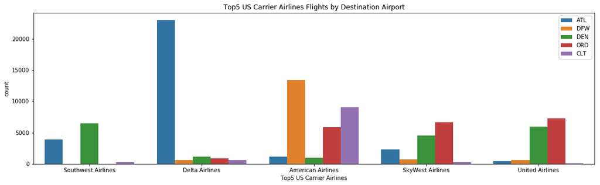

```python
df7=flights.query('DEST=="ATL" or DEST=="ORD" or DEST=="DFW" or DEST=="DEN" or DEST=="CLT"')
ct_counts = df7.groupby(['VClass', 'DEST']).size()
# Use Series.reset_index() to convert a series into a dataframe object
ct_counts = ct_counts.reset_index(name='count')
# Use DataFrame.pivot() to rearrange the data, to have vehicle class on rows
ct_counts = ct_counts.pivot(index = 'VClass', columns = 'DEST', values = 'count')
ct_counts
#sb.heatmap(ct_counts)
sb.countplot(data = df7, x = 'VClass', hue = 'DEST')
plt.title("Top5 US Carrier Airlines Flights by Destination Airport")
plt.xlabel("Top5 US Carrier Airlines")
plt.legend(loc='upper right');
```

- ATL are the most DEST Airport flights lunches by Delta Airlines op_carrier.

# ORIGIN and DEST for TOP5 Airports in clustered bar charts

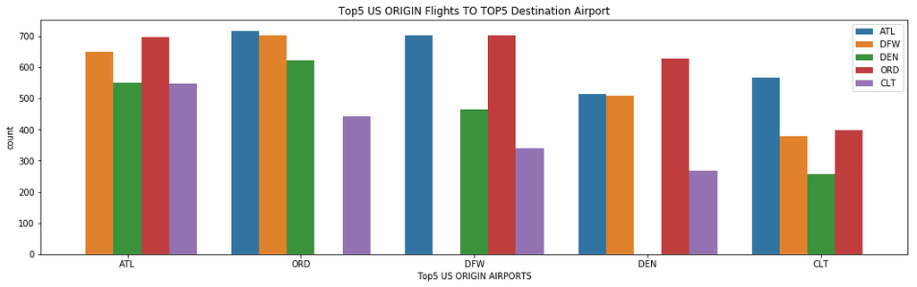

```python
#ORIGIN TO DEST
origin_classes =['ATL','ORD','DFW', 'DEN', 'CLT']
o_classes = pd.api.types.CategoricalDtype(ordered=True, categories=origin_classes)
flights['Orgin_class'] = flights['ORIGIN'].astype(o_classes);
df7=flights.query('DEST=="ATL" or DEST=="ORD" or DEST=="DFW" or DEST=="DEN" or DEST=="CLT"')
ct_counts = df7.groupby(['Orgin_class', 'DEST']).size()
# Use Series.reset_index() to convert a series into a dataframe object
ct_counts = ct_counts.reset_index(name='count')
# Use DataFrame.pivot() to rearrange the data, to have vehicle class on rows
ct_counts = ct_counts.pivot(index = 'Orgin_class', columns = 'DEST', values = 'count')
ct_counts
#sb.heatmap(ct_counts)
sb.countplot(data = df7, x = 'Orgin_class', hue = 'DEST')
plt.title("Top5 US ORIGIN Flights TO TOP5 Destination Airport")
plt.xlabel("Top5 US ORIGIN AIRPORTS")
plt.legend(loc='upper right');
```

## Multivariate Exploration

# Multiple Variables Correlations

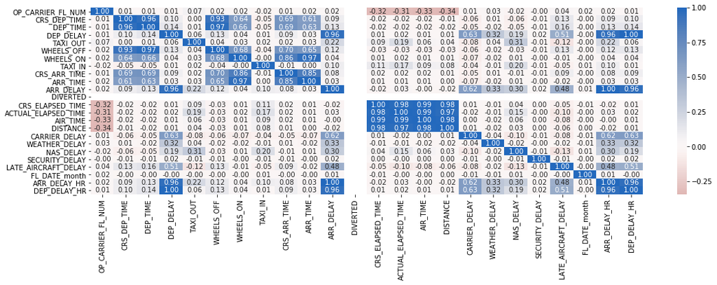

```python
sb.heatmap(flights.corr(), annot = True, fmt = '.2f', cmap = 'vlag_r', center = 0);
```

- We can find out that highly correlation between (ARR_DELAY, DEP_DELAY) , (DISTANCE,ACTUAL_ELAPSED_TIME), (ARR/DEP_DELAY, CARRIER_DELAY/LATE_AIRCRAFT_DELAY).

# Arrival Delay & Departure Delay & Flight Distance Relationship

```python
flights['ARR_DELAY'].describe()
```

```
count    672866.000000
mean          5.108464
std          47.166935
min        -117.000000
25%         -14.000000
50%          -6.000000
75%           8.000000
max        1767.000000
Name: ARR_DELAY, dtype: float64
```

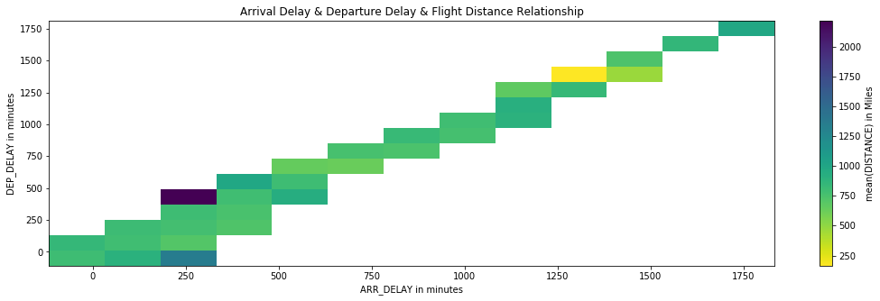

```python
xbin_edges = np.arange(-117, flights['ARR_DELAY'].max()+150, 150)
ybin_edges = np.arange(-109,    flights['DEP_DELAY'].max()+120, 120)

# count number of points in each bin
xbin_idxs = pd.cut(flights['ARR_DELAY'], xbin_edges, right = False,
                    include_lowest = True, labels = False).astype(int)
ybin_idxs = pd.cut(flights['DEP_DELAY'], ybin_edges, right = False,
                    include_lowest = True, labels = False).astype(int)

pts_per_bin = flights.groupby([xbin_idxs, ybin_idxs]).size()
pts_per_bin = pts_per_bin.reset_index()
pts_per_bin = pts_per_bin.pivot(index = 'ARR_DELAY', columns = 'DEP_DELAY').values

z_wts = flights['DISTANCE'] / pts_per_bin[xbin_idxs, ybin_idxs]

# plot the data using the calculated weights
plt.hist2d(data = flights, x = 'ARR_DELAY', y = 'DEP_DELAY', weights = z_wts,
           bins = [xbin_edges, ybin_edges], cmap = 'viridis_r', cmin = 0.5);
plt.title("Arrival Delay & Departure Delay & Flight Distance Relationship")
plt.xlabel('ARR_DELAY in minutes')
plt.ylabel('DEP_DELAY in minutes');
plt.colorbar(label = 'mean(DISTANCE) in Miles');
```

# Arrival Delay & Actual Elapsed Time & Flight Distance Relationship

[figure not shown]

```python
plt.scatter(data = flights, c = 'ARR_DELAY', y = 'ACTUAL_ELAPSED_TIME', x = 'DISTANCE')
plt.title("Arrival Delay & Actual Elapsed Time & Flight Distance Relationship")
plt.xlabel('ARR_DELAY in minutes')
plt.ylabel('Actual Elapsed Time in minutes');
plt.colorbar(label = 'mean(DISTANCE) in Miles');
```

# Distance & Actual Elapsed Time & TOP5 US Airlines Relationship

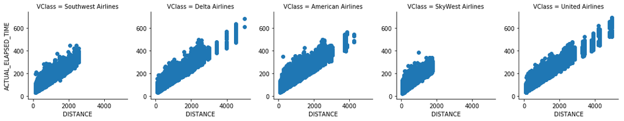

```python
g = sb.FacetGrid(data = flights, col = 'VClass',
                margin_titles = True)
g.map(plt.scatter, 'DISTANCE', 'ACTUAL_ELAPSED_TIME')
```

- We can find out that Delta Airlines & United Airlines made long distant trip that took large Elapsed time as well. That makes sense as Distance & Actual Elapsed Time are postively correlated.